# Project 2C: Galton Data

Bradley Freitag, Cindy Candelario Jose

Thursday, April 14, 2022 @ 01:25 PM

## Setup

### Packages Used

```r
library(tidyverse)
library(readr)
```

### Datasets Used

#### Background of the Data

Francis Galton, a cousin of Charles Darwin, studied the relationship between parent heights and the heights of their offspring. His pioneering [1886 article](https://galton.org/essays/1880-1889/galton-1886-jaigi-regression-stature.pdf) is the first appearance of regression analysis in print. He originated many statistical terms and concepts, including regression, correlation, deviate, quartile, and percentile, plus median for the midpoint of a distribution. The `galtonheightdata` dataset was [created under the direction of Dr. James A. Hanley](http://www.medicine.mcgill.ca/epidemiology/hanley/galton/) using Galton’s [original paper notebooks](http://www.medicine.mcgill.ca/epidemiology/hanley/galton/notebook/index.html) containing the measurement data. You can access the `galtonfamiliesmain.csv` and `galtonfamiliessub.csv` datasets from the [description](https://stat-jet-asu.github.io/Datasets/InstructorDescriptions/galtonheightdata.html) page. A third dataset, `galtonfamiliesnotebook.csv`, shows the notebook page on which each family’s information was recorded.

#### Galton Main Dataset

```r
galton_main <- read_csv("https://raw.githubusercontent.com/STAT-JET-ASU/Datasets/master/Instructor/galtonfamiliesmain.csv")
```

#### Galton Subset Dataset

```r
galton_sub <- read_csv("https://raw.githubusercontent.com/STAT-JET-ASU/Datasets/master/Instructor/galtonfamiliessub.csv")
```

#### Galton Notebook Dataset

```r
galton_notebook <- read_csv("https://raw.githubusercontent.com/STAT-JET-ASU/Datasets/master/Instructor/galtonfamiliesnotebook.csv")
```

## Analyses

### Create the Analysis Datasets

#### Dataset #1

Load the three Galton datasets and use `glimpse()` to explore their structures. Refer to Project 1 and use the new data binding/joining skills you have learned to assemble a single dataset that meets the following criteria. Use `glimpse()` and `head()` to display the result. (Hint: Use `bind_rows()` to connect the `main` and `sub` datasets, then use a join to add the `notebook` information.)

- contains these variables:
  - `familyid` = ID number of the family, with `136A` recoded as `205`
  - `page` = the notebook page on which the family is recorded
  - `num_children`= the number of children in the family
  - `father_ht` = the height of the father
  - `mother_ht` = the “transmuted” (per Galton) height of the mother
  - `midparent` = the average of the parents’ heights (using transmuted mother)
  - `child_sex`= whether the child is a son or a daughter, in all lower case
  - `child_ht` = the height of the child with daughter heights “transmuted”
- is arranged according to:
  - ascending order of familyid
  - sons before daughters within family
  - in order of height within each sex of child

```r
glimpse(galton_main)
```

```
Rows: 898
Columns: 6
$ FamilyID <chr> "1", "1", "1", "1", "2", "2", "2", "2", "3", "3", "4", "4", "…
$ Children <dbl> 4, 4, 4, 4, 4, 4, 4, 4, 2, 2, 5, 5, 5, 5, 5, 6, 6, 6, 6, 6, 6…
$ Father   <dbl> 78.5, 78.5, 78.5, 78.5, 75.5, 75.5, 75.5, 75.5, 75.0, 75.0, 7…
$ Mother   <dbl> 67.0, 67.0, 67.0, 67.0, 66.5, 66.5, 66.5, 66.5, 64.0, 64.0, 6…
$ Child    <chr> "Son", "Daughter", "Daughter", "Daughter", "Son", "Son", "Dau…
$ Height   <dbl> 73.2, 69.2, 69.0, 69.0, 73.5, 72.5, 65.5, 65.5, 71.0, 68.0, 7…
```

```r
glimpse(galton_sub)
```

```
Rows: 36
Columns: 6
$ FamilyID <dbl> 13, 13, 50, 50, 84, 84, 84, 84, 84, 111, 120, 120, 120, 120, …
$ Children <dbl> 2, 2, 2, 2, 4, 4, 4, 4, 4, 1, 11, 11, 11, 11, 11, 11, 11, 11,…
$ FatherR  <dbl> 13.0, 13.0, 11.0, 11.0, 10.5, 10.5, 10.5, 10.5, 10.5, 9.0, 9.…
$ MotherR  <dbl> 7.0, 7.0, 5.4, 5.4, 3.0, 3.0, 3.0, 3.0, 3.0, 3.5, 2.0, 2.0, 2…
$ Child    <chr> "Son", "Daughter", "Son", "Daughter", "Son", "Son", "Son", "D…
$ HeightR  <dbl> 11.0, 2.0, 13.0, 2.0, 10.0, 8.5, 5.5, 5.5, 3.5, 5.5, 12.0, 10…
```

```r
glimpse(galton_notebook)
```

```
Rows: 205
Columns: 2
$ FamilyID <chr> "1", "2", "3", "4", "5", "6", "7", "8", "9", "10", "11", "12"…
$ Page     <dbl> 1, 1, 1, 1, 1, 1, 1, 1, 1, 1, 1, 1, 1, 1, 1, 1, 1, 1, 1, 1, 1…
```

```r
galton_main1 <- galton_main %>%
   mutate(
      FamilyID = as.numeric(ifelse(FamilyID == "136A", 205, FamilyID)),
   mother_ht = 1.08 * Mother,
   midparent = (mother_ht + Father) / 2,
   child_ht = if_else(Child == "Daughter", 1.08 * Height, Height)
   ) %>%
  rename(father_ht = Father, child_sex = Child, num_children = Children, familyid = FamilyID) %>%
   select(-Mother, familyid, -Height, num_children, father_ht, mother_ht, midparent, child_sex, child_ht)

head(galton_main1)
```

```
# A tibble: 6 × 7
  familyid num_children father_ht child_sex mother_ht midparent child_ht
     <dbl>        <dbl>     <dbl> <chr>         <dbl>     <dbl>    <dbl>
1        1            4      78.5 Son            72.4      75.4     73.2
2        1            4      78.5 Daughter       72.4      75.4     74.7
3        1            4      78.5 Daughter       72.4      75.4     74.5
4        1            4      78.5 Daughter       72.4      75.4     74.5
5        2            4      75.5 Son            71.8      73.7     73.5
6        2            4      75.5 Son            71.8      73.7     72.5
```

```r
galton_sub1 <- galton_sub %>%
   mutate(
         father_ht = FatherR + 60,
         mother = MotherR + 60,
         HeightR = HeightR + 60,
         mother_ht = 1.08 * mother,
         child_ht = if_else(Child == "Daughter", 1.08 * HeightR, HeightR),
         midparent = (father_ht + mother_ht) / 2) %>%
   select(
       familyid = FamilyID,
       num_children = Children,
       father_ht,
       -FatherR,
       -MotherR,
       -mother,
       mother_ht,
       midparent,
       child_sex = Child,
       -HeightR,
       child_ht)  %>%
  arrange(familyid,
          desc(child_sex),
          desc(child_ht))

head(galton_sub1)
```

```
# A tibble: 6 × 7
  familyid num_children father_ht mother_ht midparent child_sex child_ht
     <dbl>        <dbl>     <dbl>     <dbl>     <dbl> <chr>        <dbl>
1       13            2      73        72.4      72.7 Son           71
2       13            2      73        72.4      72.7 Daughter      67.0
3       50            2      71        70.6      70.8 Son           73
4       50            2      71        70.6      70.8 Daughter      67.0
5       84            4      70.5      68.0      69.3 Son           70
6       84            4      70.5      68.0      69.3 Son           68.5
```

```r
galton_notebook1 <- galton_notebook %>%
   mutate(
      familyid = as.numeric(ifelse(FamilyID == "136A", 205, FamilyID))) %>%
   select(familyid, page = Page)

head(galton_notebook1)
```

```
# A tibble: 6 × 2
  familyid  page
     <dbl> <dbl>
1        1     1
2        2     1
3        3     1
4        4     1
5        5     1
6        6     1
```

```r
galton_mainsub <- bind_rows(galton_main1, galton_sub1)

head(galton_mainsub)
```

```
# A tibble: 6 × 7
  familyid num_children father_ht child_sex mother_ht midparent child_ht
     <dbl>        <dbl>     <dbl> <chr>         <dbl>     <dbl>    <dbl>
1        1            4      78.5 Son            72.4      75.4     73.2
2        1            4      78.5 Daughter       72.4      75.4     74.7
3        1            4      78.5 Daughter       72.4      75.4     74.5
4        1            4      78.5 Daughter       72.4      75.4     74.5
5        2            4      75.5 Son            71.8      73.7     73.5
6        2            4      75.5 Son            71.8      73.7     72.5
```

```r
galton_dataset1 <- full_join(galton_mainsub, galton_notebook1, by = "familyid") %>%
   arrange(familyid,
           desc(child_sex),
           desc(child_ht))

head(galton_dataset1)
```

```
# A tibble: 6 × 8
  familyid num_children father_ht child_sex mother_ht midparent child_ht  page
     <dbl>        <dbl>     <dbl> <chr>         <dbl>     <dbl>    <dbl> <dbl>
1        1            4      78.5 Son            72.4      75.4     73.2     1
2        1            4      78.5 Daughter       72.4      75.4     74.7     1
3        1            4      78.5 Daughter       72.4      75.4     74.5     1
4        1            4      78.5 Daughter       72.4      75.4     74.5     1
5        2            4      75.5 Son            71.8      73.7     73.5     1
6        2            4      75.5 Son            71.8      73.7     72.5     1
```

#### Dataset #2

From Dataset #1, select the variables `familyid` and `num_children`, then reduce the dataset so it contains only one unique row per family. Use `glimpse()` to display the result. (Hint: The final dataset should have 205 rows/observations and two variables/columns.)

```r
galton_dataset2 <- galton_dataset1 %>%
   select(familyid, num_children) %>%
   distinct()

glimpse(galton_dataset2)
```

```
Rows: 205
Columns: 2
$ familyid     <dbl> 1, 2, 3, 4, 5, 6, 7, 8, 9, 10, 11, 12, 13, 14, 15, 16, 17…
$ num_children <dbl> 4, 4, 2, 5, 6, 1, 6, 3, 1, 1, 8, 1, 2, 2, 3, 9, 6, 3, 1, …
```

```r
head(galton_dataset2)
```

```
# A tibble: 6 × 2
  familyid num_children
     <dbl>        <dbl>
1        1            4
2        2            4
3        3            2
4        4            5
5        5            6
6        6            1
```

### Visualization 1: Updated Scatterplot

#### Galton’s Visualization

In his original paper (linked above), Galton created several tables and diagrams. His “Diagram Based on Table 1” of them is similar in concept to a scatterplot. Rather than dots, he grouped/tabulated the data, and then used the count of how many people were grouped at the coordinate pairs in his grid, with child as the x-axis and mid-parent as the y-axis. There are two scales: inches and deviations from 68.25 inches.

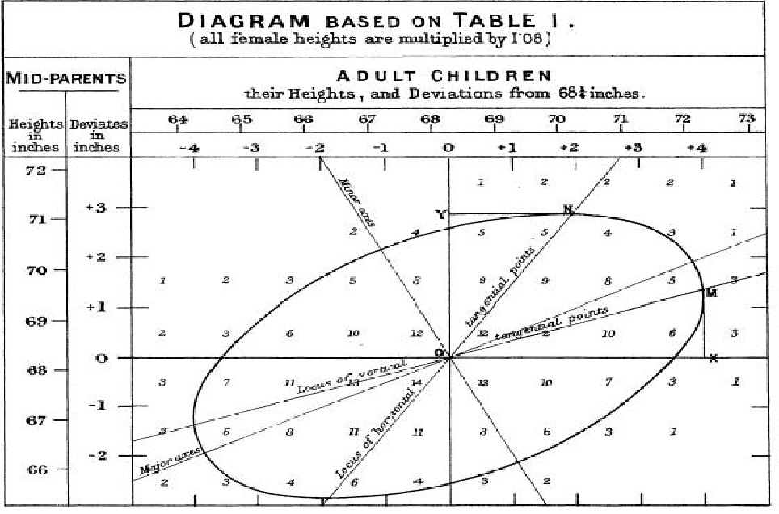

#### Your Data Visualization

**This plot uses Dataset #1.**

Create a scatterplot of child height (x-axis) versus mid-parent height (y-axis). Ordinarily, we might reverse the axes here because analysts would be more likely to model child height as a function of parent height, but we want to be able to compare the updated plot to Galton’s original.

Include the following.

- make your dots larger than the default size to help show density
- set transparency to adjust for overplotting and help show density
- use `color =` in the `aes` to differentiate sons versus daughters
- use `scale_color_manual()` to choose two colorblind-safe colors
- scale both axes so that there is a tick mark at every whole inch
- use `coord_fixed()` so that the axes have the same unit spacing
- add better x- and y-axis labels, including the units of measure
- add an informative title (you may optionally include a subtitle)
- add `color =` to `labs()` to set the legend title to `"gender of child"`
- use a built-in theme (e.g., `theme_linedraw()`) to add formatting
- use `theme()` to move the legend to the bottom of the scatterplot

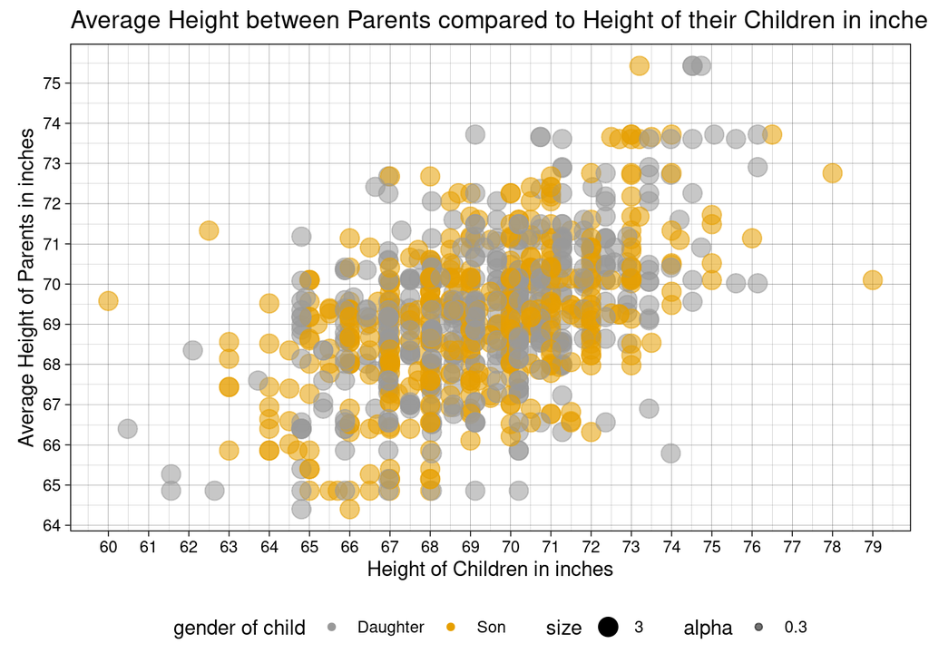

```r
cbPalette <- c("#999999", "#E69F00", "#56B4E9", "#009E73", "#F0E442", "#0072B2", "#D55E00", "#CC79A7")

ggplot(galton_dataset1, mapping = aes(child_ht, midparent, size = 3, alpha = 0.3, color = child_sex)) +
   geom_point() +
   scale_color_manual(values = cbPalette) +
   scale_x_continuous(breaks = seq(60, 80, by = 1)) +
   scale_y_continuous(breaks = seq(60, 80, by = 1)) +
   coord_fixed() +
   labs(title = "Average Height between Parents compared to Height of their Children in inches", x = "Height of Children in inches", y = "Average Height of Parents in inches", color = "gender of child") +
   theme_linedraw() +
   theme(legend.position = "bottom")
```

### Visualization 2: Number of Children

**This plot uses Dataset #2.**

Create a barplot to show the distribution of the number of children per family. Set the bars to something other than the default `width`. Scale the x-axis so that there is a tick mark for each bar. Choose appropriate colors, labels, themes, and/or and other types of formatting that you feel will enhance the meaning or visual appearance of the plot. (Hint: Use `count()` to find out how many families have a given number of children, then use that information to create your plot.)

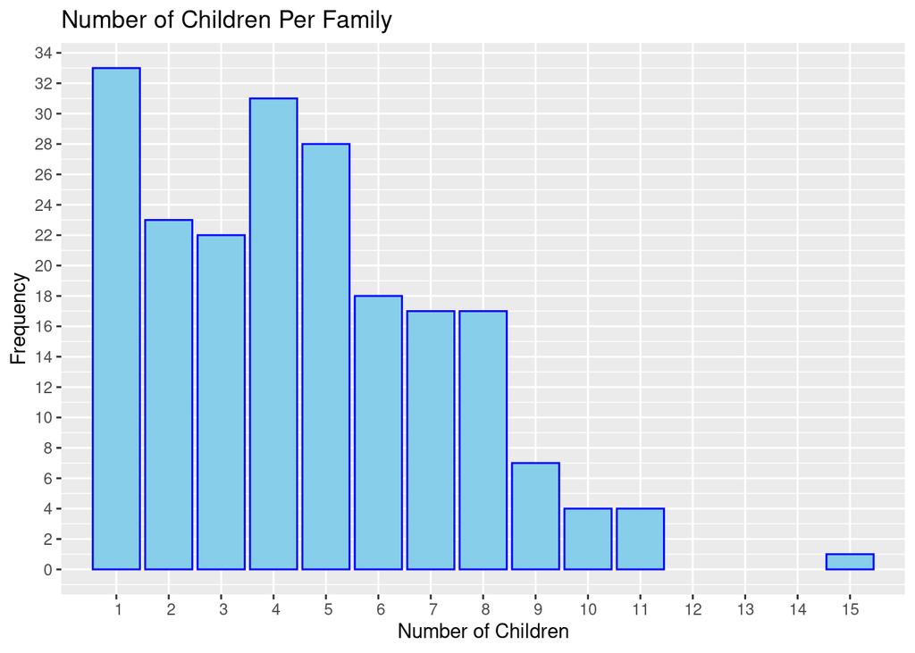

```r
galton_children <- galton_dataset2 %>% count(num_children)

ggplot(galton_children, aes(x = num_children, weight = n, width = 10)) + geom_bar(color = "blue", fill = "skyblue")+
   labs(title = "Number of Children Per Family",
       x = "Number of Children",
       y = "Frequency") +
    scale_x_discrete(limits = seq(1, 15, 1)) +
    scale_y_continuous(breaks = seq(0, 40, 2))
```

```r
    scale_fill_manual(values = c())
```

[output not shown]

## Questions

**Question 1:** Do you think your scatterplot is an improvement over Galton’s original diagram? Are there any other modifications and/or additions you would make to enhance the clarity or usefulness of your plot?

**ANSWER**

Despite the inherent muddiness of my graph and its central points, graphing Galton’s data on a cartesian plane better visualizes the data than Galton’s asymmetric polar plane diagram. The cartesian plane is more sensible for comparing the two variables, since both variables are now on linear axes as opposed to one variable. My graph’s overall sizing and aspect could be better, but I am still somewhat unfamiliar with the nuances of the best data visualization practices with ggplot2. Additionally, I had difficulty using the `scale_*_continuous` functions to make the axes start on the same number. However, I still consider my graph more cohesive and useful than Galton’s original diagram.

**Question 2:** Explain the rationale behind the choices you made when creating your scatterplot and barplot, such as size, color, transparency, or other features. What motivated your decisions?

**Question 3:** Considering best practices, how does using `coord_fixed()` enhance the authenticity of the information shown in the scatterplot, such as the relationship and spread of the data?

**ANSWER**

Using `coord_fixed()`ensures that the size of individual graph units on the x-axis is equivalent to the size of individual graph units on the y-axis. Thus, the equivalency of the axes accurately displays the data. By fixing the aspect ratio to equivalent measurements, the value of each observation is relative to each variable’s measurement and, thanks to the transformation of the height units for mothers and daughters, accurately depicts a visual representation of child height compared to midparent height. The relationship between the variables in inches applies Galton’s data authentically, as opposed to the polar diagram.